# SingleCellAnalysisWorkshop_2023 Book2

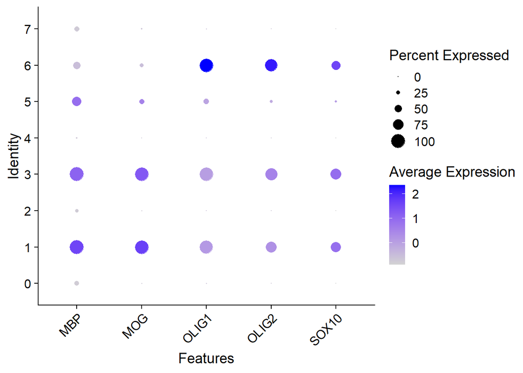

```r
DotPlot(integrated_seurat, features = oligodendrocyte, group.by = "integrated_snn_res.0.4") + RotatedAxis()
```

Cluster 1,3,5 have mature oligodendrocyte markers and cluster 6 has strong oligo lineage markers

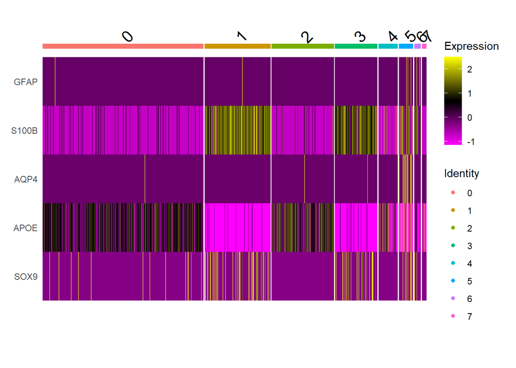

```r
# astrocyte
DoHeatmap(integrated_seurat, features = astrocytes, group.by = "integrated_snn_res.0.4")
```

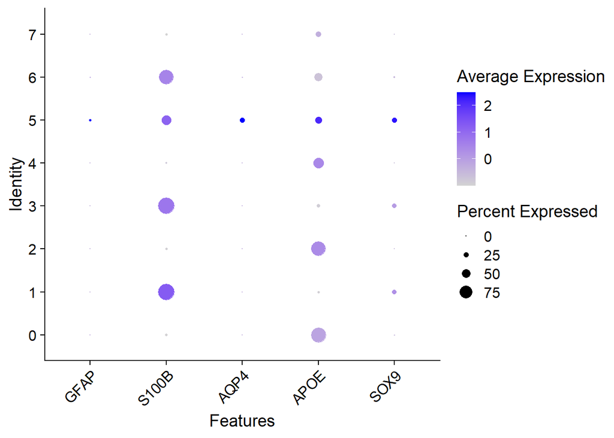

```r
DotPlot(integrated_seurat, features = astrocytes, group.by = "integrated_snn_res.0.4") + RotatedAxis()
```

Cluster 5 is the best match for astrocyte markers

```r
#saveRDS(integrated_seurat, file = "integrated_seurat.Rds")
```

Automated cell type annotation

scClassify R weighted kNN https://doi.org/10.15252/msb.20199389

https://sydneybiox.github.io/scClassify/articles/scClassify.html

```r
# we need to create the reference matrices
#matrices where each row is a gene and each column a cell for a reference dataset and a query data set

# reference data
# we have the data prepared as a Seurat object

ref <- readRDS("data/Karolinski_DevForebrain_downsample_Level1.RDS")
ref
```

```
## An object of class Seurat
## 60662 features across 5311 samples within 1 assay
## Active assay: RNA (60662 features, 2000 variable features)
##  1 dimensional reduction calculated: pca
```

```r
#check the meta data
colnames(ref@meta.data)
```

```
## [1] "orig.ident"   "nCount_RNA"   "nFeature_RNA" "Sample"       "Level1"
## [6] "Age"          "Clusters"     "New"          "Celltypes"
```

```r
unique(ref$Clusters)
```

```
##  [1] "Neuroblast motorneuron/GABAergic?"
##  [2] "Radial Glia cycling"
##  [3] "Glioblast"
##  [4] "Cortical Interneurons"
##  [5] "Excitatory neurons midbrain"
##  [6] "Excitatory neurons possibly midbrain"
##  [7] "OPCs"
##  [8] "Microglia"
##  [9] "Excitatory neurons cortex"
## [10] "Forebrain early neuroblast possibly GABAergic"
## [11] "GABAergic forebrain"
## [12] "Cortical Pyramidal"
## [13] "Radial Glia"
## [14] "Radial Glia potential glioblast"
## [15] "Radial Glia VLMC primed?"
## [16] "Glioblast/Pre-OPC"
## [17] "Forebrain neural progenitor EMX1"
## [18] "Endothelial"
## [19] "Striatum/Cortical neurons"
## [20] "Radial glia/Glioblast/Forebrain progenitor EMX1"
## [21] "Forebrain inhibitory neuroblast"
## [22] "VLMCs"
## [23] "Inhibitory neurons Midbrain, possibly GABAergic"
## [24] "Hindbrain neuroblast"
## [25] "Radial Glia/Glioblast"
## [26] "GABAergic or interneuron neuroblast probably midbrain"
## [27] "Midbrain inhibitory neuroblast"
## [28] "U"
## [29] "Mid/Hindbrain neuroblast"
## [30] "Midbrain/Hindbrain inhibitory neuroblast"
```

```r
unique(ref$Level1)
```

```
##  [1] "EarlyExcitatory"  "RadialGlia"       "Glioblast"        "EarlyInhibitory"
##  [5] "NeuralProgenitor" "OPC"              "30"               "29"
##  [9] "VLMC"             "31"
```

```r
unique(ref$Celltypes)
```

```
##  [1] Neuroblast  RG          Glioblast   IN          EN          OPC
##  [7] Microglia   Pre-OPC     NPC         Endothelial Neurons     VLMC
## [13] U
## 13 Levels: Neuroblast RG Glioblast IN EN OPC Microglia Pre-OPC ... U
```

```r
# make a new meta data with fewer cell types.
```

We need to make the reference and query objects into a “dgCMatrix” object

```r
# make a dfCMatrix from Seurat object to use in scClassify

dgCMat_ref <- GetAssayData(ref)
# get the cell type data
Idents(ref) <- "Celltypes"
ref_celltypes <- Idents(ref)
unique(ref_celltypes)
```

```
##  [1] Neuroblast  RG          Glioblast   IN          EN          OPC
##  [7] Microglia   Pre-OPC     NPC         Endothelial Neurons     VLMC
## [13] U
## 13 Levels: Neuroblast RG Glioblast IN EN OPC Microglia Pre-OPC ... U
```

```r
# convert the integrated clustered object into dgCMatrix
DefaultAssay(integrated_seurat) <- "RNA"
dgCMat_query <- GetAssayData(integrated_seurat)
Idents(integrated_seurat) <- "Original_clusterID"
query_celltypes <- Idents(integrated_seurat)

# check the objects
dim(dgCMat_ref)
```

```
## [1] 60662  5311
```

```r
dim(dgCMat_query)
```

```
## [1] 20116  9044
```

```r
class(dgCMat_ref)
```

```
## [1] "dgCMatrix"
## attr(,"package")
## [1] "Matrix"
```

```r
class(dgCMat_query)
```

```
## [1] "dgCMatrix"
## attr(,"package")
## [1] "Matrix"
```

See the original cell type annotations

```r
table(ref_celltypes)
```

```
## ref_celltypes
##  Neuroblast          RG   Glioblast          IN          EN         OPC
##         638        1097         365         952        1353          98
##   Microglia     Pre-OPC         NPC Endothelial     Neurons        VLMC
##          43         211         262          58          47          97
##           U
##          90
```

```r
table(query_celltypes)
```

```
## query_celltypes
##       Microglia Oligodendrocyte       Astrocyte             OPC
##            3180            1113              59             101
```

```r
length(ref_celltypes)
```

```
## [1] 5311
```

```r
length(query_celltypes)
```

```
## [1] 9044
```

We can now perform non-ensemble scClassify

```r
scClassify_res <- scClassify(exprsMat_train = dgCMat_ref,
                             cellTypes_train = ref_celltypes,
                             exprsMat_test = dgCMat_query,
                             cellTypes_test = query_celltypes,
                             tree = "HOPACH",
                             algorithm = "WKNN",
                             selectFeatures = c("limma"),
                             similarity = c("pearson"),
                             returnList = FALSE,
                             verbose = FALSE)
```

We can check the cell type tree generated by the reference data:

```r
scClassify_res$trainRes
```

```
## Class: scClassifyTrainModel
## Model name: training
## Feature selection methods: limma
## Number of cells in the training data: 5311
## Number of cell types in the training data: 13
```

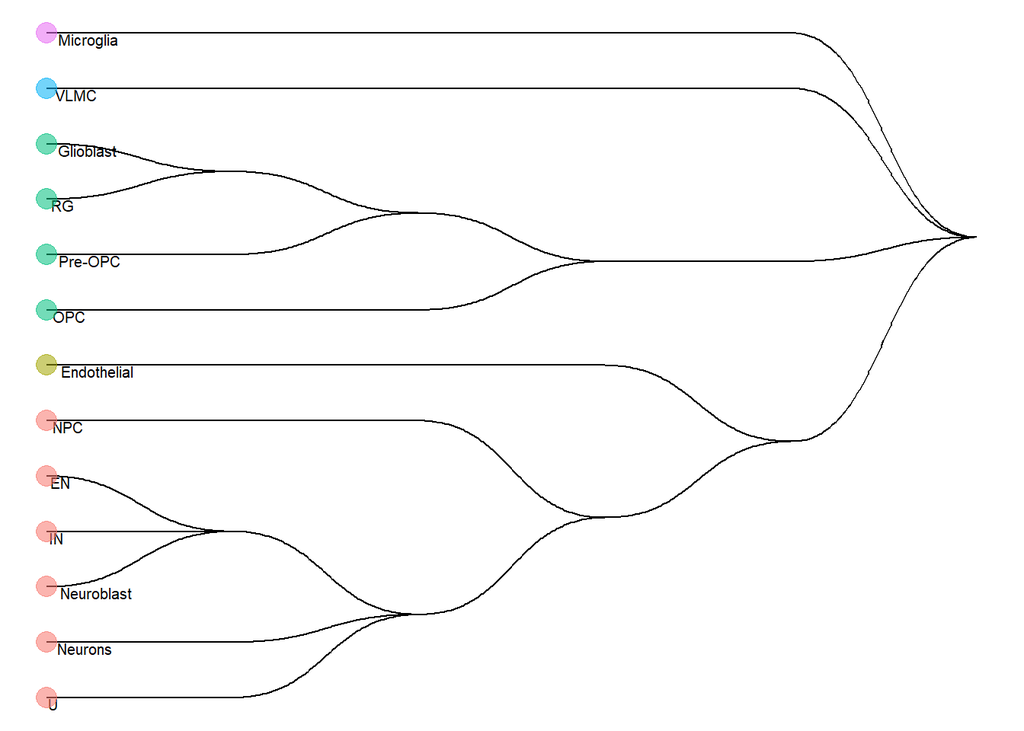

```r
plotCellTypeTree(cellTypeTree(scClassify_res$trainRes))
```

Check the predictions

```r
table(scClassify_res$testRes$test$pearson_WKNN_limma$predRes,query_celltypes)
```

```
##                           query_celltypes
##                            Microglia Oligodendrocyte Astrocyte  OPC
##   Endothelial                      1               0         1    0
##   Glioblast                        0               0         0    0
##   IN                               0               0         0    0
##   Microglia                     3178               9        20    1
##   Neuroblast_IN_EN                 0               1         0    0
##   OPC                              0             985         0   99
##   Pre-OPC                          0               1        31    0
##   RG                               0               0         0    0
##   RG_Glioblast_OPC_Pre-OPC         0               7         0    0
##   RG_Glioblast_Pre-OPC             0               2         2    0
##   unassigned                       1             106         4    1
##   VLMC                             0               2         1    0
```

We want to predict cluster labels

```r
# we need to make the test meta data into the cluster ids
Idents(integrated_seurat) <- "integrated_snn_res.0.4"
query_clusters <- Idents(integrated_seurat)


scClassify_res <- scClassify(exprsMat_train = dgCMat_ref,
                             cellTypes_train = ref_celltypes,
                             exprsMat_test = dgCMat_query,
                             cellTypes_test = query_clusters,
                             tree = "HOPACH",
                             algorithm = "WKNN",
                             selectFeatures = c("limma"),
                             similarity = c("pearson"),
                             returnList = FALSE,
                             verbose = FALSE)
```

See the cell type predictions by cluster and add the predicted labels to the Seurat object

```r
table(scClassify_res$testRes$test$pearson_WKNN_limma$predRes,query_clusters)
```

```
##                           query_clusters
##                               0    1    2    3    4    5    6    7
##   Endothelial                 0    0    0    0    2    0    0    4
##   Glioblast                   0    0    0    0    0    2    0    0
##   IN                          0    0    0    0    0    1    0    0
##   Microglia                3857   10 1495   77  447   20    6   95
##   Neuroblast_IN_EN            0    0    0    1    0    6    0    0
##   OPC                         0 1528    0  776    2  102  153    0
##   Pre-OPC                     0    0    0    1    2  117    0    0
##   RG                          0    0    0    0    0    2    0    1
##   RG_Glioblast_OPC_Pre-OPC    0    4    0    3    3   12    0    0
##   RG_Glioblast_Pre-OPC        0    2    0    0    1   11    0    0
##   unassigned                  0   40    1  164    7   70    1   13
##   VLMC                        0    1    0    1    1    1    0    1
```

```r
meta_to_add <- scClassify_res$testRes$test$pearson_WKNN_limma$predRes %>%
                enframe %>%
                as.data.frame %>%
                column_to_rownames("name") %>%
                setNames(nm = c("Karolinski"))
integrated_seurat <- AddMetaData(integrated_seurat, meta_to_add)
```

Check another reference set

```r
# refrence data
# we have the data prepared as a Seurat object

ref2 <- readRDS("data/Nowakowski_dev_cortext.RDS")
ref2
```

```
## An object of class Seurat
## 56865 features across 4261 samples within 1 assay
## Active assay: RNA (56865 features, 2000 variable features)
##  1 dimensional reduction calculated: pca
```

```r
#check the meta data
colnames(ref2@meta.data)
```

```
##  [1] "orig.ident"   "nCount_RNA"   "nFeature_RNA" "WGCNAcluster" "Name"
##  [6] "Age_in_Weeks" "RegionName"   "Laminae"      "Area"         "Celltypes"
```

```r
#make the reference matrix and reference cell types


dgCMat_ref2 <- GetAssayData(ref2)
# get the cell type data
Idents(ref2) <- "Celltypes"

levels(ref2)
```

```
##  [1] "Glyc"        "RG"          "EN"          "IN"          "IPC"
##  [6] "OPC"         "Mural"       "MGE"         "Astrocyte"   "Endothelial"
## [11] "Microglia"   "Choroid"     "U"
```

```r
ref_celltypes2 <- as.character(Idents(ref2))
ref_celltypes2[is.na(ref_celltypes2)] <- "NA"

unique(ref_celltypes2)
```

```
##  [1] "Glyc"        "RG"          "EN"          "IN"          "IPC"
##  [6] "OPC"         "Mural"       "NA"          "MGE"         "Astrocyte"
## [11] "Endothelial" "Microglia"   "Choroid"     "U"
```

```r
# check the object
dim(dgCMat_ref2)
```

```
## [1] 56865  4261
```

```r
class(dgCMat_ref2)
```

```
## [1] "dgCMatrix"
## attr(,"package")
## [1] "Matrix"
```

```r
# predict the cluster cell types from the second reference
scClassify_res <- scClassify(exprsMat_train = dgCMat_ref2,
                             cellTypes_train = ref_celltypes2,
                             exprsMat_test = dgCMat_query,
                             cellTypes_test = query_clusters,
                             tree = "HOPACH",
                             algorithm = "WKNN",
                             selectFeatures = c("limma"),
                             similarity = c("pearson"),
                             returnList = FALSE,
                             verbose = FALSE)
```

```
## There are only 0 selected genes in reference data expressed in query data
```

```r
#Add the predicted labels to the Seurat object

meta_to_add <- scClassify_res$testRes$test$pearson_WKNN_limma$predRes %>%
                enframe %>%
                as.data.frame %>%
                column_to_rownames("name") %>%
                setNames(nm = c("Nowakowski"))
integrated_seurat <- AddMetaData(integrated_seurat, meta_to_add)
```

Now that we have the an different forms of information to annotate the cells we need to decide on the annotations to add, then add them into the data object.

```r
# we need to set the identity to rename
Idents(integrated_seurat) <- "integrated_snn_res.0.4"

# we need to make a vector of the cell type in the same order - in the cluster order

cell_types <- c("microglia","oligodendrocytes_1","embyonic_microglia",
                "oligodendrocyte_2","immune", "astrocytes","OPC","monocytes")

names(cell_types) <- levels(integrated_seurat)
integrated_seurat <- RenameIdents(integrated_seurat, cell_types)
integrated_seurat <- AddMetaData(object=integrated_seurat, metadata=Idents(integrated_seurat), col.name = "CellTypes")
```

Save the integrated object for next steps

```r
saveRDS(integrated_seurat, file = "integrated_seurat.Rds")

Sys.time()
```

```
## [1] "2023-05-07 15:12:54 EDT"
```